# Validation set vs training set LDA training - Approach two CIFAR10

```r
library(ggplot2)
library(dplyr)
library(tidyr)
library("ggpubr")
```

This experiment focuses on the question, whether training linear combining method on the same set of data as the neural networks were trained on has any adverse effects to the performance of the ensemble as opposed to training on a different set, not presented to the networks during the training. Experiment was performed with two slightly different approaches.

Approach two Experiment code is in the file half_train_ensembling_experiment.py. Experiment on both CIFAR10 and CIFAR100 datasets. This experiment differs from the previous one in the neural networks training part. In this case, the networks were trained on half of the original training set. The remainder of the training set was extracted as a validation set. This enabled us to train several ensembles on both the training set and the validation set in each replication. Experiment on CIFAR10 was performed in 1 replication and experiment on CIFAR100 in 10 replications. This is due to 10 times more classes in CIFAR100 and thus a need for 10 times larger combiner training set in order to maintain constant 50 samples for class in combiner models training.

Approach one is described in the file visualization_base_experiment.

# CIFAR10

```r
net_results <- read.csv("../data/data_train_val_half_c10/net_accuracies.csv")
ens_results <- read.csv("../data/data_train_val_half_c10/ensemble_accuracies.csv")
```

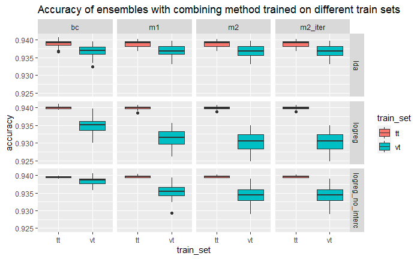

```r
box_acc <- ggplot() + geom_boxplot(data=ens_results, mapping = aes(x=train_set, y=accuracy, fill=train_set)) +
  facet_grid(rows=vars(combining_method), cols=vars(coupling_method)) +
  ggtitle("Accuracy of ensembles with combining method trained on different train sets")
box_acc
```

Training on the same training data as the neural networks were trained on seems to provide better accuracy compared to training on separate validation set.

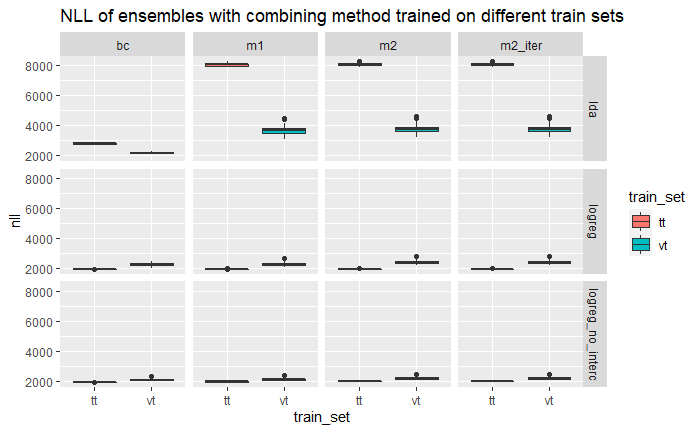

```r
box_nll <- ggplot() + geom_boxplot(data=ens_results, mapping = aes(x=train_set, y=nll, fill=train_set)) +
  facet_grid(rows=vars(combining_method), cols=vars(coupling_method)) +
  ggtitle("NLL of ensembles with combining method trained on different train sets")
box_nll
```

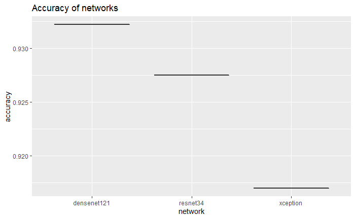

```r
box_net_acc <- ggplot() + geom_boxplot(data=net_results, mapping=aes(x=network, y=accuracy)) +
  ggtitle("Accuracy of networks")
box_net_acc
```

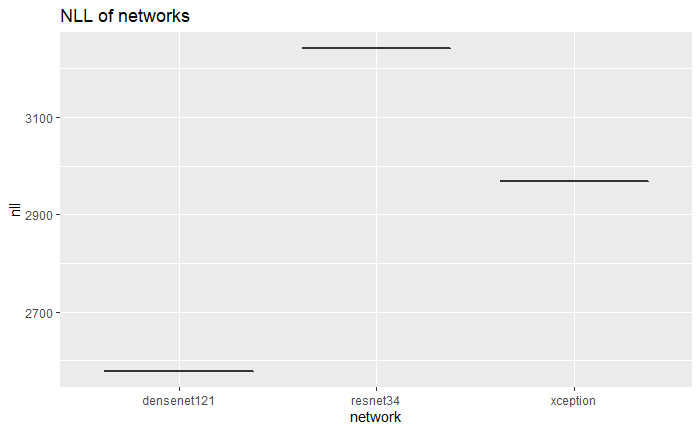

```r
box_net_nll <- ggplot() + geom_boxplot(data=net_results, mapping=aes(x=network, y=nll)) +
  ggtitle("NLL of networks")
box_net_nll
```

```r
ens_results_wide <- pivot_wider(ens_results, names_from = c(train_set, coupling_method), values_from = c(accuracy, nll))
```

Testing statistical significance of difference for training on validation and train data. We have 50 samples from each distribution, so we will suppose the distributions are normal.

### LDA

```r
ens_results_wide_lda <- ens_results_wide %>% filter(combining_method=="lda")
t.test(ens_results_wide_lda$accuracy_vt_m1, ens_results_wide_lda$accuracy_tt_m1)
```

```
    Welch Two Sample t-test

data:  ens_results_wide_lda$accuracy_vt_m1 and ens_results_wide_lda$accuracy_tt_m1
t = -7.5052, df = 75.254, p-value = 1.02e-10
alternative hypothesis: true difference in means is not equal to 0
95 percent confidence interval:
 -0.00247009 -0.00143391
sample estimates:
mean of x mean of y
 0.936942  0.938894
```

```r
t.test(ens_results_wide_lda$accuracy_vt_m1, ens_results_wide_lda$accuracy_tt_m1, alternative="less")
```

```
    Welch Two Sample t-test

data:  ens_results_wide_lda$accuracy_vt_m1 and ens_results_wide_lda$accuracy_tt_m1
t = -7.5052, df = 75.254, p-value = 5.098e-11
alternative hypothesis: true difference in means is less than 0
95 percent confidence interval:
         -Inf -0.001518864
sample estimates:
mean of x mean of y
 0.936942  0.938894
```

```r
t.test(ens_results_wide_lda$accuracy_vt_m2, ens_results_wide_lda$accuracy_tt_m2)
```

```
    Welch Two Sample t-test

data:  ens_results_wide_lda$accuracy_vt_m2 and ens_results_wide_lda$accuracy_tt_m2
t = -7.9408, df = 75.126, p-value = 1.531e-11
alternative hypothesis: true difference in means is not equal to 0
95 percent confidence interval:
 -0.002554261 -0.001529739
sample estimates:
mean of x mean of y
 0.936852  0.938894
```

```r
t.test(ens_results_wide_lda$accuracy_vt_m2, ens_results_wide_lda$accuracy_tt_m2, alternative="less")
```

```
    Welch Two Sample t-test

data:  ens_results_wide_lda$accuracy_vt_m2 and ens_results_wide_lda$accuracy_tt_m2
t = -7.9408, df = 75.126, p-value = 7.655e-12
alternative hypothesis: true difference in means is less than 0
95 percent confidence interval:
        -Inf -0.00161374
sample estimates:
mean of x mean of y
 0.936852  0.938894
```

```r
t.test(ens_results_wide_lda$accuracy_vt_m2_iter, ens_results_wide_lda$accuracy_tt_m2_iter)
```

```
    Welch Two Sample t-test

data:  ens_results_wide_lda$accuracy_vt_m2_iter and ens_results_wide_lda$accuracy_tt_m2_iter
t = -7.9408, df = 75.126, p-value = 1.531e-11
alternative hypothesis: true difference in means is not equal to 0
95 percent confidence interval:
 -0.002554261 -0.001529739
sample estimates:
mean of x mean of y
 0.936852  0.938894
```

```r
t.test(ens_results_wide_lda$accuracy_vt_m2_iter, ens_results_wide_lda$accuracy_tt_m2_iter, alternative="less")
```

```
    Welch Two Sample t-test

data:  ens_results_wide_lda$accuracy_vt_m2_iter and ens_results_wide_lda$accuracy_tt_m2_iter
t = -7.9408, df = 75.126, p-value = 7.655e-12
alternative hypothesis: true difference in means is less than 0
95 percent confidence interval:
        -Inf -0.00161374
sample estimates:
mean of x mean of y
 0.936852  0.938894
```

```r
t.test(ens_results_wide_lda$accuracy_vt_bc, ens_results_wide_lda$accuracy_tt_bc)
```

```
    Welch Two Sample t-test

data:  ens_results_wide_lda$accuracy_vt_bc and ens_results_wide_lda$accuracy_tt_bc
t = -8.6163, df = 81.215, p-value = 4.473e-13
alternative hypothesis: true difference in means is not equal to 0
95 percent confidence interval:
 -0.002693235 -0.001682765
sample estimates:
mean of x mean of y
 0.936854  0.939042
```

```r
t.test(ens_results_wide_lda$accuracy_vt_bc, ens_results_wide_lda$accuracy_tt_bc, alternative="less")
```

```
    Welch Two Sample t-test

data:  ens_results_wide_lda$accuracy_vt_bc and ens_results_wide_lda$accuracy_tt_bc
t = -8.6163, df = 81.215, p-value = 2.237e-13
alternative hypothesis: true difference in means is less than 0
95 percent confidence interval:
         -Inf -0.001765491
sample estimates:
mean of x mean of y
 0.936854  0.939042
```

### LogReg

```r
ens_results_wide_logreg <- ens_results_wide %>% filter(combining_method=="logreg")
t.test(ens_results_wide_logreg$accuracy_vt_m1, ens_results_wide_logreg$accuracy_tt_m1)
```

```
    Welch Two Sample t-test

data:  ens_results_wide_logreg$accuracy_vt_m1 and ens_results_wide_logreg$accuracy_tt_m1
t = -24.439, df = 51.61, p-value < 2.2e-16
alternative hypothesis: true difference in means is not equal to 0
95 percent confidence interval:
 -0.009185064 -0.007790936
sample estimates:
mean of x mean of y
 0.931478  0.939966
```

```r
t.test(ens_results_wide_logreg$accuracy_vt_m1, ens_results_wide_logreg$accuracy_tt_m1, alternative="less")
```

```
    Welch Two Sample t-test

data:  ens_results_wide_logreg$accuracy_vt_m1 and ens_results_wide_logreg$accuracy_tt_m1
t = -24.439, df = 51.61, p-value < 2.2e-16
alternative hypothesis: true difference in means is less than 0
95 percent confidence interval:
         -Inf -0.007906276
sample estimates:
mean of x mean of y
 0.931478  0.939966
```

```r
t.test(ens_results_wide_logreg$accuracy_vt_m2, ens_results_wide_logreg$accuracy_tt_m2)
```

```
    Welch Two Sample t-test

data:  ens_results_wide_logreg$accuracy_vt_m2 and ens_results_wide_logreg$accuracy_tt_m2
t = -25.5, df = 51.272, p-value < 2.2e-16
alternative hypothesis: true difference in means is not equal to 0
95 percent confidence interval:
 -0.010286665 -0.008785335
sample estimates:
mean of x mean of y
 0.930396  0.939932
```

```r
t.test(ens_results_wide_logreg$accuracy_vt_m2, ens_results_wide_logreg$accuracy_tt_m2, alternative="less")
```

```
    Welch Two Sample t-test

data:  ens_results_wide_logreg$accuracy_vt_m2 and ens_results_wide_logreg$accuracy_tt_m2
t = -25.5, df = 51.272, p-value < 2.2e-16
alternative hypothesis: true difference in means is less than 0
95 percent confidence interval:
         -Inf -0.008909567
sample estimates:
mean of x mean of y
 0.930396  0.939932
```

```r
t.test(ens_results_wide_logreg$accuracy_vt_m2_iter, ens_results_wide_logreg$accuracy_tt_m2_iter)
```

```
    Welch Two Sample t-test

data:  ens_results_wide_logreg$accuracy_vt_m2_iter and ens_results_wide_logreg$accuracy_tt_m2_iter
t = -25.5, df = 51.272, p-value < 2.2e-16
alternative hypothesis: true difference in means is not equal to 0
95 percent confidence interval:
 -0.010286665 -0.008785335
sample estimates:
mean of x mean of y
 0.930396  0.939932
```

```r
t.test(ens_results_wide_logreg$accuracy_vt_m2_iter, ens_results_wide_logreg$accuracy_tt_m2_iter, alternative="less")
```

```
    Welch Two Sample t-test

data:  ens_results_wide_logreg$accuracy_vt_m2_iter and ens_results_wide_logreg$accuracy_tt_m2_iter
t = -25.5, df = 51.272, p-value < 2.2e-16
alternative hypothesis: true difference in means is less than 0
95 percent confidence interval:
         -Inf -0.008909567
sample estimates:
mean of x mean of y
 0.930396  0.939932
```

```r
t.test(ens_results_wide_logreg$accuracy_vt_bc, ens_results_wide_logreg$accuracy_tt_bc)
```

```
    Welch Two Sample t-test

data:  ens_results_wide_logreg$accuracy_vt_bc and ens_results_wide_logreg$accuracy_tt_bc
t = -16.641, df = 52.45, p-value < 2.2e-16
alternative hypothesis: true difference in means is not equal to 0
95 percent confidence interval:
 -0.005995007 -0.004704993
sample estimates:
mean of x mean of y
 0.934692  0.940042
```

```r
t.test(ens_results_wide_logreg$accuracy_vt_bc, ens_results_wide_logreg$accuracy_tt_bc, alternative="less")
```

```
    Welch Two Sample t-test

data:  ens_results_wide_logreg$accuracy_vt_bc and ens_results_wide_logreg$accuracy_tt_bc
t = -16.641, df = 52.45, p-value < 2.2e-16
alternative hypothesis: true difference in means is less than 0
95 percent confidence interval:
        -Inf -0.00481167
sample estimates:
mean of x mean of y
 0.934692  0.940042
```

### LogReg without intercept

```r
ens_results_wide_logreg_ni <- ens_results_wide %>% filter(combining_method=="logreg_no_interc")
t.test(ens_results_wide_logreg_ni$accuracy_vt_m1, ens_results_wide_logreg_ni$accuracy_tt_m1)
t.test(ens_results_wide_logreg_ni$accuracy_vt_m1, ens_results_wide_logreg_ni$accuracy_tt_m1, alternative="less")

t.test(ens_results_wide_logreg_ni$accuracy_vt_m2, ens_results_wide_logreg_ni$accuracy_tt_m2)
t.test(ens_results_wide_logreg_ni$accuracy_vt_m2, ens_results_wide_logreg_ni$accuracy_tt_m2, alternative="less")

t.test(ens_results_wide_logreg_ni$accuracy_vt_m2_iter, ens_results_wide_logreg_ni$accuracy_tt_m2_iter)
t.test(ens_results_wide_logreg_ni$accuracy_vt_m2_iter, ens_results_wide_logreg_ni$accuracy_tt_m2_iter, alternative="less")

t.test(ens_results_wide_logreg_ni$accuracy_vt_bc, ens_results_wide_logreg_ni$accuracy_tt_bc)
t.test(ens_results_wide_logreg_ni$accuracy_vt_bc, ens_results_wide_logreg_ni$accuracy_tt_bc, alternative="less")
```

[output not shown]

For all coupling methods, we found, that ensemble models trained on subset (of size 500) of the neural networks training set have statistically significantly better accuracy than ensemble models trained on separate validation set (of the same size).